# HOG2

Check if your python interpreter is linked to jupyter notebook by printing a simple statement.

```python
print('HOG-descriptor-from-scratch')
```

```
HOG-descriptor-from-scratch
```

The path where this ipython script is present also contains 'Data' folder. The data folder has following structure:

> data

> ->pedestrians128x64

> ->pedestrians_neg

> ->img_test

You can download data folder from:

> https://drive.google.com/file/d/1YCXkb2muHz-m-nqNWtxCfuxa817DaWB6/view?usp=sharing

```python
datadir = "data"
dataset = "pedestrians128x64"
datafile = "%s/%s.tar.gz" % (datadir, dataset)
```

```python
extractdir = "%s/%s" % (datadir, dataset)
```

```python
import cv2
import matplotlib.pyplot as plt
%matplotlib inline
```

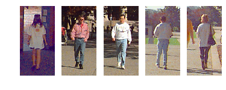

```python
for i in range(5):
    filename = "%s/per0010%d.ppm" % (extractdir, i)
    img = cv2.imread(filename)
    plt.subplot(1, 5, i + 1)
    plt.imshow(cv2.cvtColor(img, cv2.COLOR_BGR2RGB))
    plt.axis('off')
```

HOG descriptor is used in open cv by calling cv2.HOGDescriptor function this function requires the following input arguments.

- detection window size
- block size
- cell size
- cell stride

```python
win_size = (48, 96)
block_size = (16, 16)
block_stride = (8, 8)
cell_size = (8, 8)
num_bins = 9
hog = cv2.HOGDescriptor(win_size, block_size, block_stride,
                        cell_size, num_bins)
```

X-pos list contains randomly picked positive samples of pedestrians. Then apply hog descriptor to them

```python
import numpy as np
import random
random.seed(42)
X_pos = []
for i in random.sample(range(900), 400):
    filename = "%s/per%05d.ppm" % (extractdir, i)
    img = cv2.imread(filename)
    if img is None:
        print('Could not find image %s' % filename)
        continue
    X_pos.append(hog.compute(img, (64, 64)))
```

```
Could not find image data/pedestrians128x64/per00000.ppm
```

I picked 399 training images each of them have 1980 hog feature values.

```python
X_pos = np.array(X_pos, dtype=np.float32)
y_pos = np.ones(X_pos.shape[0], dtype=np.int32)
X_pos.shape, y_pos.shape
```

```
((399, 1980, 1), (399,))
```

```python
negdir = "%s/pedestrians_neg" % datadir
```

I loop through all the negative images in the directory using os.listdir() and cut out a 64 x 128 region of interest (ROI):

```python
import os
hroi = 128
wroi = 64
X_neg = []
for negfile in os.listdir(negdir):
    filename = '%s/%s' % (negdir, negfile)
    img = cv2.imread(filename)
    img = cv2.resize(img, (512, 512))
    for j in range(5):
        rand_y = random.randint(0, img.shape[0] - hroi)
        rand_x = random.randint(0, img.shape[1] - wroi)
        roi = img[rand_y:rand_y + hroi, rand_x:rand_x + wroi, :]
        X_neg.append(hog.compute(roi, (64, 64)))
```

```python
X_neg = np.array(X_neg, dtype=np.float32)
y_neg = -np.ones(X_neg.shape[0], dtype=np.int32)
X_neg.shape, y_neg.shape
```

```
((250, 1980, 1), (250,))
```

```python
X = np.concatenate((X_pos, X_neg))
y = np.concatenate((y_pos, y_neg))
```

```python
from sklearn import model_selection as ms
X_train, X_test, y_train, y_test = ms.train_test_split(
    X, y, test_size=0.2, random_state=42
)
```

Here I train SVM

```python
def train_svm(X_train, y_train):
    svm = cv2.ml.SVM_create()
    svm.train(X_train, cv2.ml.ROW_SAMPLE, y_train)
    return svm
```

```python
def score_svm(svm, X, y):
    from sklearn import metrics
    _, y_pred = svm.predict(X)
    return metrics.accuracy_score(y, y_pred)
```

After training SVM I find training scores and testing scores

```python
svm = train_svm(X_train, y_train)
score_svm(svm, X_train, y_train)
```

```
1.0
```

```python
score_svm(svm, X_test, y_test)
```

```
0.6461538461538462
```

The training score is much higher than the testing score, this is a problem of overfitting. To tackle this problem of overfitting I find fasle positive in the test set once they are found I append them to the training set. And repet this for 2 rounds as you can see I got 64% accuracy in the first round and 100% accuracy in the second round.

```python
score_train = []
score_test = []
for j in range(3):
    svm = train_svm(X_train, y_train)
    score_train.append(score_svm(svm, X_train, y_train))
    score_test.append(score_svm(svm, X_test, y_test))
    _, y_pred = svm.predict(X_test)
    false_pos = np.logical_and((y_test.ravel() == -1),
                               (y_pred.ravel() == 1))
    if not np.any(false_pos):
        print('no more false positives: done')
        break
    X_train = np.concatenate((X_train,
                              X_test[false_pos, :]),
                             axis=0)
    y_train = np.concatenate((y_train, y_test[false_pos]),
                             axis=0)
```

```
no more false positives: done
```

```python
score_train
```

```
[1.0, 1.0]
```

```python
score_test
```

```
[0.6461538461538462, 1.0]
```

Now that I have made a fairly accurate model I should move on to detection. Divide image into small squares and find out if each square contains pedestrian or not. For this I use 'stride' feature, stride is nothing but number of pixels. I made sure I dont cross boundry of image by using

> if ystart + hroi > img_test.shape[0]:

> if xstart + wroi > img_test.shape[1]:

After this I find region of interest. If the ROI is classified as a pedestrian then I add it to list of successes using this code

> if np.allclose(ypred, 1): found.append((ystart, xstart, hroi, wroi))

```python
stride = 16
found = []
img_test = cv2.imread('img_test.jpg')
for ystart in np.arange(0, img_test.shape[0], stride):
    for xstart in np.arange(0, img_test.shape[1], stride):
        if ystart + hroi > img_test.shape[0]:
            continue
        if xstart + wroi > img_test.shape[1]:
             continue
        roi = img_test[ystart:ystart + hroi,
                       xstart:xstart + wroi, :]
        feat = np.array([hog.compute(roi, (64, 64))])
        _, ypred = svm.predict(feat)

        if np.allclose(ypred, 1):
            found.append((ystart, xstart, hroi, wroi))
```

```python
rho, _, _ = svm.getDecisionFunction(0)
sv = svm.getSupportVectors()
hog.setSVMDetector(np.append(sv.ravel(), rho))
```

[output not shown]

The size of people can vary hence I use detectMultiScale

```python
found = hog.detectMultiScale(img_test)
```

[output not shown]

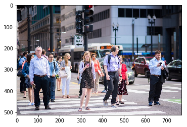

```python
from matplotlib import patches
fig = plt.figure()
ax = fig.add_subplot(111)
ax.imshow(cv2.cvtColor(img_test, cv2.COLOR_BGR2RGB))

for f in found:
    ax.add_patch(patches.Rectangle((f[0], f[1]), f[2], f[3],
                                   color='y', linewidth=3,
                                   fill=False))
```